# Coursera Practical Machine Learning

## Background

Using devices such as Jawbone Up, Nike FuelBand, and Fitbit it is now possible to collect a large amount of data about personal activity relatively inexpensively. These type of devices are part of the quantified self movement - a group of enthusiasts who take measurements about themselves regularly to improve their health, to find patterns in their behavior, or because they are tech geeks. One thing that people regularly do is quantify how much of a particular activity they do, but they rarely quantify how well they do it. In this project, your goal will be to use data from accelerometers on the belt, forearm, arm, and dumbell of 6 participants. They were asked to perform barbell lifts correctly and incorrectly in 5 different ways. More information is available from the website here: http://web.archive.org/web/20161224072740/http:/groupware.les.inf.puc-rio.br/har. (see the section on the Weight Lifting Exercise Dataset).

## Data

The training data for this project are available here:

https://d396qusza40orc.cloudfront.net/predmachlearn/pml-training.csv

The test data are available here:

https://d396qusza40orc.cloudfront.net/predmachlearn/pml-testing.csv

If you want to read more: Velloso, E.; Bulling, A.; Gellersen, H.; Ugulino, W.; Fuks, H. Qualitative Activity Recognition of Weight Lifting Exercises. Proceedings of 4th International Conference in Cooperation with SIGCHI (Augmented Human ’13) . Stuttgart, Germany: ACM SIGCHI, 2013.

## Reading and preparing the data

```r
training <- read.csv("https://d396qusza40orc.cloudfront.net/predmachlearn/pml-training.csv")
testing <- read.csv("https://d396qusza40orc.cloudfront.net/predmachlearn/pml-testing.csv")
```

## Exploring the data

```r
dim(training)
```

```
## [1] 19622   160
```

```r
# str(training)
table(training$classe)
```

```
##
##    A    B    C    D    E
## 5580 3797 3422 3216 3607
```

The training dataset consists of 19622 observations on 160 variables. All observations have to do with weight lifting execises of 6 young adults: exactly according to the specifications (Classe = A), and four other manners corresponding to common misstakes (classe = B, C, D or E). The goal of this project is to predict the manner in which exercises were performed (classe). The distribution of classe is shown above.

The training dataset is split in a training-set and a validation-set: 70/30. The training-set is used to build models and the validation-set is used to validate the models. The testing-dataset will only be used to generate the quiz results.

```r
inTrain <- createDataPartition(training$classe, p = 0.70, list = FALSE)
trainSet <- training[inTrain, ]
testSet <- training[-inTrain, ]
dim(trainSet)
```

```
## [1] 13737   160
```

```r
dim(testSet)
```

```
## [1] 5885  160
```

```r
table(trainSet$classe); prop.table(table(trainSet$classe))
```

```
##
##    A    B    C    D    E
## 3906 2658 2396 2252 2525
```

```
##
##         A         B         C         D         E
## 0.2843416 0.1934920 0.1744195 0.1639368 0.1838101
```

```r
table(testSet$classe); prop.table(table(testSet$classe))
```

```
##
##    A    B    C    D    E
## 1674 1139 1026  964 1082
```

```
##
##         A         B         C         D         E
## 0.2844520 0.1935429 0.1743415 0.1638063 0.1838573
```

## Selecting variables: removing identifying variables

In a first step all identifying variables are removed:

```r
# removing identification variables (1:5)
trainSet <- trainSet[ , -(1:5)]
testSet <- testSet[ , -(1:5)]
dim(trainSet)
```

```
## [1] 13737   155
```

```r
# dim(testSet)
```

In this step 5 variables are removed, leaving 155 of the 160 original variables in the dataframe.

## Selecting variables: removing missing values

In a next step, missing values are evaluated. Although best practice would be to look at the underlying process of missingness, in this case only the amount of missingness is considered. All variables with 90% or more missing values are removed form the training- and the testset:

```r
# removing variables with 90% or more missing values (NA)
nnaVars <- sapply(trainSet, function(x) mean(is.na(x))) > 0.90
nnaVars <- which(nnaVars)
trainSet <- trainSet[ , -nnaVars]
testSet <- testSet[, -nnaVars]
dim(trainSet)
```

```
## [1] 13737    88
```

```r
# dim(testset)
```

## Selecting variables: removing (near) zero variance variables

In the next step variance of the predictors is considered. All variables with zero or near zero variance are removed from both the training- and the testset:

```r
# removing variables with Near Zero Variance
nzVars <- nearZeroVar(trainSet)
trainSet <- trainSet[ , -nzVars]
testSet <- testSet[, -nzVars]
dim(trainSet)
```

```
## [1] 13737    54
```

```r
# dim(testSet)
```

This step removed 34 of the remaining 88 variables, resulting in a datafram of only 54 variables.

## Selecting variables: removing highly correlating variables

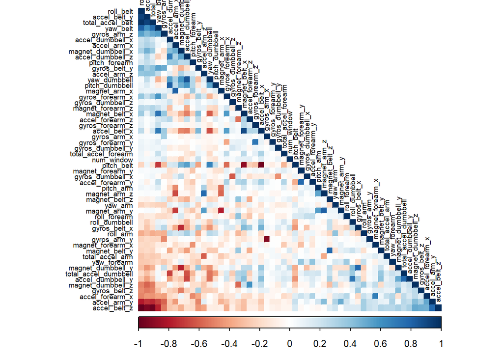

```r
# looking at the correlations between the numerical predictors
corMatrix <- cor(trainSet[, -54])
corrplot(corMatrix, order = "FPC", method = "color", type = "lower", tl.cex = 0.6, tl.col = rgb(0, 0, 0))
```

```r
# removing higly correlated predictors (cor > 0.85)
hcVar <- findCorrelation(corMatrix, cutoff = 0.85)
hcVar
```

```
## [1] 11  2 10 37  9  3 19
```

```r
trainSet <- trainSet[ , -hcVar]
testSet <- testSet[, -hcVar]
dim(trainSet)
```

```
## [1] 13737    47
```

```r
# dim(testSet)
```

## Fitting prediction models

In this part five different models will be fitted to the trainingdata (and evaluated against the testdata).

## Random Forest (RF)

```r
# Random Forest
set.seed(131055)
trControl <- trainControl(method = "cv", number = 5, verboseIter = FALSE)
mod_rf <- train(classe ~ ., data = trainSet, method = "rf", trControl = trControl)
# mod_rf$finalModel; suppress: to much output
predict_rf <- predict(mod_rf, newdata = testSet)
confMat_rf <- confusionMatrix(predict_rf, testSet$classe)
confMat_rf
```

```
## Confusion Matrix and Statistics
##
##           Reference
## Prediction    A    B    C    D    E
##          A 1673    3    0    0    0
##          B    0 1133    5    0    0
##          C    0    3 1021    3    0
##          D    0    0    0  960    1
##          E    1    0    0    1 1081
##
## Overall Statistics
##
##                Accuracy : 0.9971
##                  95% CI : (0.9954, 0.9983)
##     No Information Rate : 0.2845
##     P-Value [Acc > NIR] : < 2.2e-16
##
##                   Kappa : 0.9963
##  Mcnemar's Test P-Value : NA
##
## Statistics by Class:
##
##                      Class: A Class: B Class: C Class: D Class: E
## Sensitivity            0.9994   0.9947   0.9951   0.9959   0.9991
## Specificity            0.9993   0.9989   0.9988   0.9998   0.9996
## Pos Pred Value         0.9982   0.9956   0.9942   0.9990   0.9982
## Neg Pred Value         0.9998   0.9987   0.9990   0.9992   0.9998
## Prevalence             0.2845   0.1935   0.1743   0.1638   0.1839
## Detection Rate         0.2843   0.1925   0.1735   0.1631   0.1837
## Detection Prevalence   0.2848   0.1934   0.1745   0.1633   0.1840
## Balanced Accuracy      0.9993   0.9968   0.9969   0.9978   0.9993
```

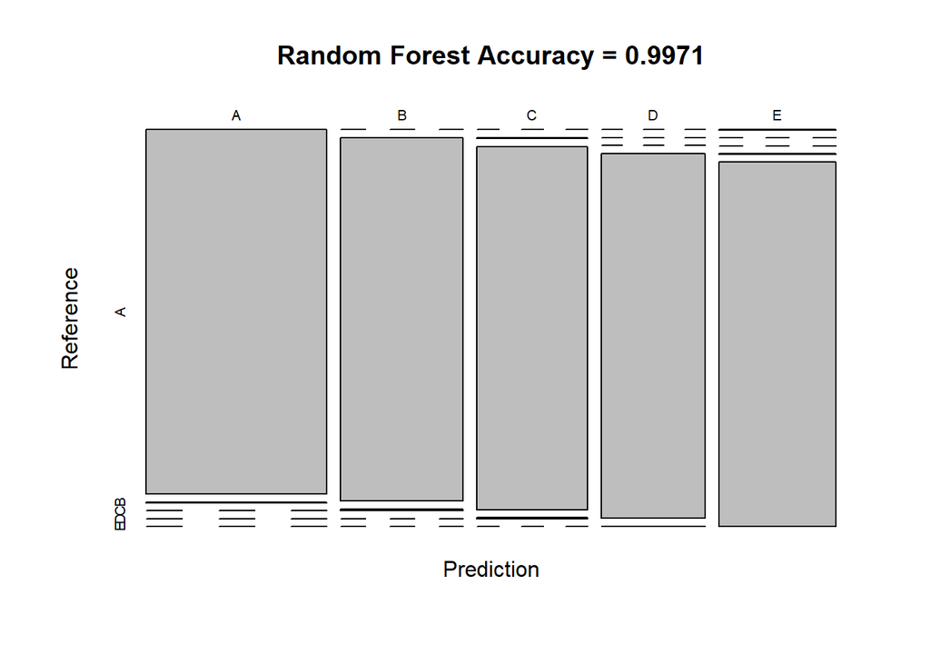

```r
plot(confMat_rf$table, main = paste("Random Forest Accuracy =", round(confMat_rf$overall["Accuracy"], 4)))
```

## Linear Discriminant Analysis (LDA)

```r
set.seed(131055)
trControl <- trainControl(method = "cv", number = 5, verboseIter = FALSE)
mod_lda <- train(classe ~ ., data = trainSet, method = "lda", trControl = trControl)
# mod_lda$finalModel; suppress: to much output
predict_lda <- predict(mod_lda, newdata = testSet)
confMat_lda <- confusionMatrix(predict_lda, testSet$classe)
confMat_lda
```

```
## Confusion Matrix and Statistics
##
##           Reference
## Prediction    A    B    C    D    E
##          A 1368  181  105   60   54
##          B   64  681   85   62  198
##          C  103  151  663  134  117
##          D  122   49  134  651  115
##          E   17   77   39   57  598
##
## Overall Statistics
##
##                Accuracy : 0.6731
##                  95% CI : (0.6609, 0.685)
##     No Information Rate : 0.2845
##     P-Value [Acc > NIR] : < 2.2e-16
##
##                   Kappa : 0.586
##  Mcnemar's Test P-Value : < 2.2e-16
##
## Statistics by Class:
##
##                      Class: A Class: B Class: C Class: D Class: E
## Sensitivity            0.8172   0.5979   0.6462   0.6753   0.5527
## Specificity            0.9050   0.9138   0.8961   0.9147   0.9604
## Pos Pred Value         0.7738   0.6248   0.5676   0.6078   0.7589
## Neg Pred Value         0.9257   0.9045   0.9230   0.9350   0.9050
## Prevalence             0.2845   0.1935   0.1743   0.1638   0.1839
## Detection Rate         0.2325   0.1157   0.1127   0.1106   0.1016
## Detection Prevalence   0.3004   0.1852   0.1985   0.1820   0.1339
## Balanced Accuracy      0.8611   0.7559   0.7711   0.7950   0.7566
```

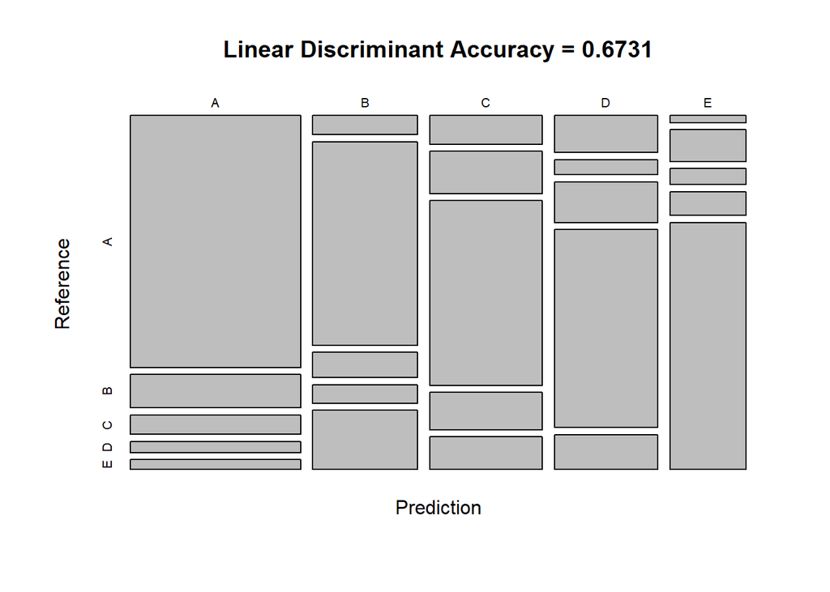

```r
plot(confMat_lda$table, main = paste("Linear Discriminant Accuracy =", round(confMat_lda$overall["Accuracy"], 4)))
```

## K Nearest Neighbor (KNN)

```r
set.seed(131055)
trControl <- trainControl(method = "cv", number = 5, verboseIter = FALSE)
mod_knn <- train(classe ~ ., data = trainSet, method = "knn", trControl = trControl)
# mod_knn$finalModel; suppress: to much output
predict_knn <- predict(mod_knn, newdata = testSet)
confMat_knn <- confusionMatrix(predict_knn, testSet$classe)
confMat_knn
```

```
## Confusion Matrix and Statistics
##
##           Reference
## Prediction    A    B    C    D    E
##          A 1617   62   12   11   11
##          B   14  991   24    3   38
##          C   16   49  956   67   20
##          D   25   19   24  871   45
##          E    2   18   10   12  968
##
## Overall Statistics
##
##                Accuracy : 0.9181
##                  95% CI : (0.9108, 0.925)
##     No Information Rate : 0.2845
##     P-Value [Acc > NIR] : < 2.2e-16
##
##                   Kappa : 0.8964
##  Mcnemar's Test P-Value : < 2.2e-16
##
## Statistics by Class:
##
##                      Class: A Class: B Class: C Class: D Class: E
## Sensitivity            0.9659   0.8701   0.9318   0.9035   0.8946
## Specificity            0.9772   0.9834   0.9687   0.9770   0.9913
## Pos Pred Value         0.9440   0.9262   0.8628   0.8852   0.9584
## Neg Pred Value         0.9863   0.9693   0.9853   0.9810   0.9766
## Prevalence             0.2845   0.1935   0.1743   0.1638   0.1839
## Detection Rate         0.2748   0.1684   0.1624   0.1480   0.1645
## Detection Prevalence   0.2911   0.1818   0.1883   0.1672   0.1716
## Balanced Accuracy      0.9716   0.9267   0.9502   0.9403   0.9429
```

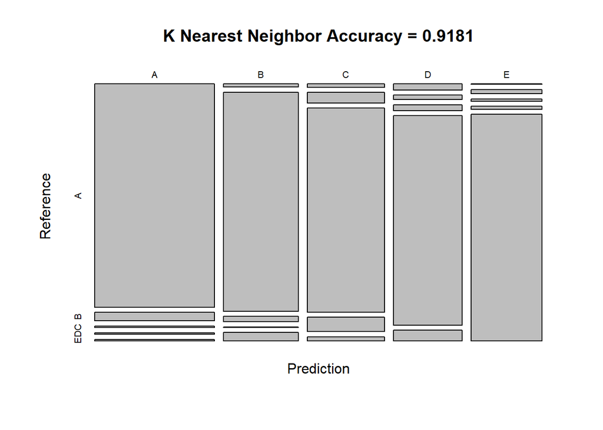

```r
plot(confMat_knn$table, main = paste("K Nearest Neighbor Accuracy =", round(confMat_knn$overall["Accuracy"], 4)))
```

## Gradient Boosting Model(GBM)

```r
set.seed(131055)
trControl <- trainControl(method = "cv", number = 5, verboseIter = FALSE)
mod_gbm <- train(classe ~ ., data = trainSet, method = "gbm", trControl = trControl, verbose = FALSE)
# mod_gbm$finalModel; suppress: to much output
predict_gbm <- predict(mod_gbm, newdata = testSet)
confMat_gbm <- confusionMatrix(predict_gbm, testSet$classe)
confMat_gbm
```

```
## Confusion Matrix and Statistics
##
##           Reference
## Prediction    A    B    C    D    E
##          A 1671    9    0    0    0
##          B    2 1122    9    3    0
##          C    0    6 1014    9    3
##          D    0    2    3  952    9
##          E    1    0    0    0 1070
##
## Overall Statistics
##
##                Accuracy : 0.9905
##                  95% CI : (0.9877, 0.9928)
##     No Information Rate : 0.2845
##     P-Value [Acc > NIR] : < 2.2e-16
##
##                   Kappa : 0.988
##  Mcnemar's Test P-Value : NA
##
## Statistics by Class:
##
##                      Class: A Class: B Class: C Class: D Class: E
## Sensitivity            0.9982   0.9851   0.9883   0.9876   0.9889
## Specificity            0.9979   0.9971   0.9963   0.9972   0.9998
## Pos Pred Value         0.9946   0.9877   0.9826   0.9855   0.9991
## Neg Pred Value         0.9993   0.9964   0.9975   0.9976   0.9975
## Prevalence             0.2845   0.1935   0.1743   0.1638   0.1839
## Detection Rate         0.2839   0.1907   0.1723   0.1618   0.1818
## Detection Prevalence   0.2855   0.1930   0.1754   0.1641   0.1820
## Balanced Accuracy      0.9980   0.9911   0.9923   0.9924   0.9944
```

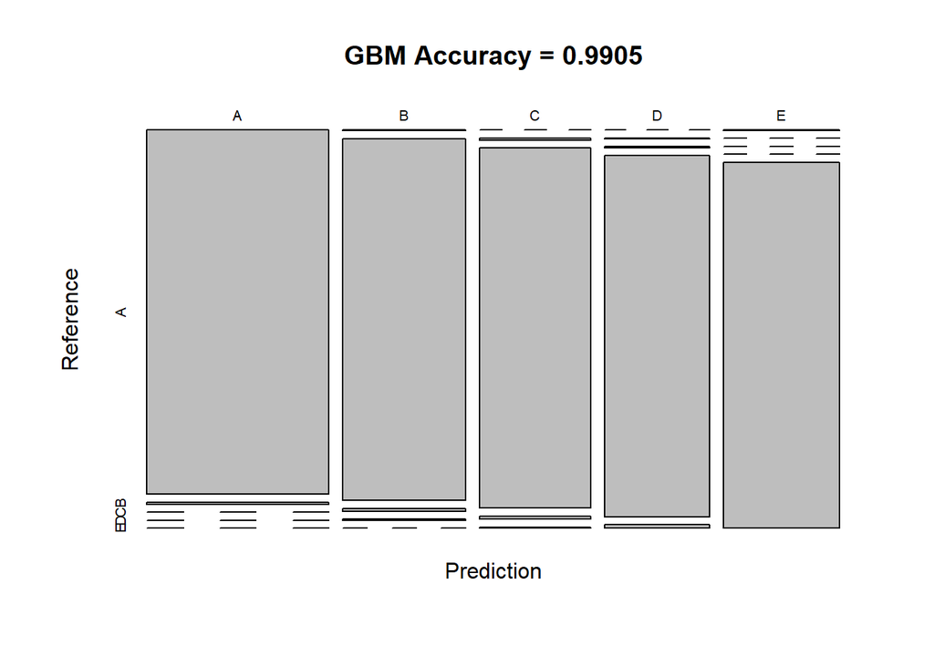

```r
plot(confMat_gbm$table, main = paste("GBM Accuracy =", round(confMat_gbm$overall["Accuracy"], 4)))
```

## Multinominal Model (MULTINOM)

```r
set.seed(131055)
trControl <- trainControl(method = "cv", number = 5, verboseIter = FALSE)
mod_multinom <- train(classe ~ ., data = trainSet, method = "multinom", trControl = trControl, trace = FALSE)
# mod_multinom$finalModel; suppress: to much output
predict_multinom <- predict(mod_multinom, newdata = testSet)
confMat_multinom <- confusionMatrix(predict_multinom, testSet$classe)
confMat_multinom
```

```
## Confusion Matrix and Statistics
##
##           Reference
## Prediction    A    B    C    D    E
##          A 1417  209  140   89  102
##          B   53  550   82   20  157
##          C   56  116  554  144   94
##          D  123  132  143  657  189
##          E   25  132  107   54  540
##
## Overall Statistics
##
##                Accuracy : 0.6318
##                  95% CI : (0.6193, 0.6441)
##     No Information Rate : 0.2845
##     P-Value [Acc > NIR] : < 2.2e-16
##
##                   Kappa : 0.5322
##  Mcnemar's Test P-Value : < 2.2e-16
##
## Statistics by Class:
##
##                      Class: A Class: B Class: C Class: D Class: E
## Sensitivity            0.8465  0.48288  0.53996   0.6815  0.49908
## Specificity            0.8718  0.93426  0.91562   0.8807  0.93379
## Pos Pred Value         0.7241  0.63805  0.57469   0.5281  0.62937
## Neg Pred Value         0.9346  0.88274  0.90408   0.9339  0.89218
## Prevalence             0.2845  0.19354  0.17434   0.1638  0.18386
## Detection Rate         0.2408  0.09346  0.09414   0.1116  0.09176
## Detection Prevalence   0.3325  0.14647  0.16381   0.2114  0.14579
## Balanced Accuracy      0.8591  0.70857  0.72779   0.7811  0.71643
```

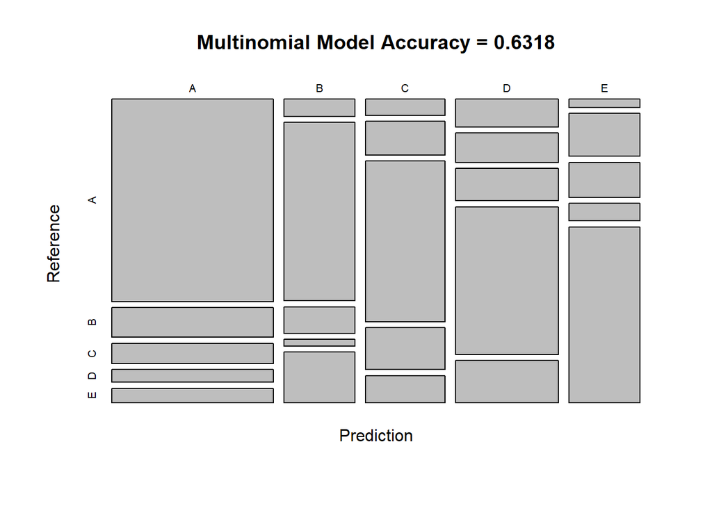

```r
plot(confMat_multinom$table, main = paste("Multinomial Model Accuracy =", round(confMat_multinom$overall["Accuracy"], 4)))
```

## Final Prediction on the Test-set

All models were trained with crossvalidation (5 folds). Sorted on performance to predict the test data, the ranking of the different models is as follows:

*1: 0.9971 (Random Forest)*  
2: 0.9905 (GBM)  
*3: 0.9181 (KNN)*  
4: 0.6731 (LDA)  
*5: 0.6318 (Multinom)

On accuracy, Random Forest is a clear winner. And it is clear from the corresponding plot that all categories of classe are more or less equally predicted.

So for the final prediction on the extra test-set of 20 observations, the final Random Forest model is choosen.

```r
predict_final <- predict(mod_rf, newdata = testing)
predict_final
```

```
##  [1] B A B A A E D B A A B C B A E E A B B B
## Levels: A B C D E
```